# Untitled

10. We have seen that as the number of features used in a model increases, the training error will necessarily decrease, but the test error may not. We will now explore this in a simulated data set.
1. Generate a data set with p =20features, n =1,000 observations, and an associated quantitative response vector generated according to the model Y = Xβ + , where β has some elements that are exactly equal to zero.

```r
set.seed(1)
p=20
n=1000
x=matrix(rnorm(n*p),n,p)
x
```

[output not shown]

[output cut: 3989 more lines]

```r
b=sample(0:10,20,replace = T)
b[5]=0
b[10]=0
b[15]=0
b[20]=0
b
```

```
##  [1] 0 9 1 3 0 8 9 1 3 0 5 7 5 7 0 2 8 0 2 0
```

```r
e=rnorm(n)
y=x%*%b+e # %*% does matrix multiplication
y
```

[output not shown]

[output cut: 986 more lines]

2. Split your data set into a training set containing 100 observations and a test set containing 900 observations.

```r
df=data.frame(x,y)
train=sample(1:1000,100)
test=-train
x.training=df[train,]
y.test=y[test]
```

3. Perform best subset selection on the training set, and plot the training set MSE associated with the best model of each size.

```r
library(leaps)
```

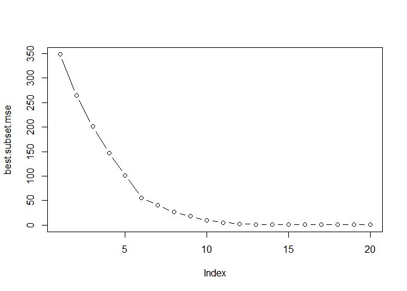

```r
best.subset=regsubsets(y~., df,subset=train, nvmax=20)
best.subset.summary=summary(best.subset)
best.subset.mse=best.subset.summary$rss/length(train)
plot(best.subset.mse,type="b")
```

(d) Plot the test set MSE associated with the best model of each size.

```r
best.test.mes=rep(NA,20)
test.mat=model.matrix(y~., data=df[-train,])
for (i in 1:20) {
    coefi = coef(best.subset, id = i)
    pred = test.mat[, names(coefi)] %*% coefi
    best.test.mes[i] = mean((df$y[-train] - pred)^2)
}
best.test.mes
```

```
##  [1] 453.979305 352.380815 288.268379 186.310549 130.569166  82.776568
##  [7]  61.127931  34.090125  23.657380  12.271485   8.027135   3.535871
## [13]   2.243814   1.230335   1.340161   1.337778   1.351459   1.365062
## [19]   1.414467   1.412026
```

```r
which.min(best.test.mes)
```

```
## [1] 14
```

```r
best.test.mes[14] #test mse=1.230335
```

```
## [1] 1.230335
```

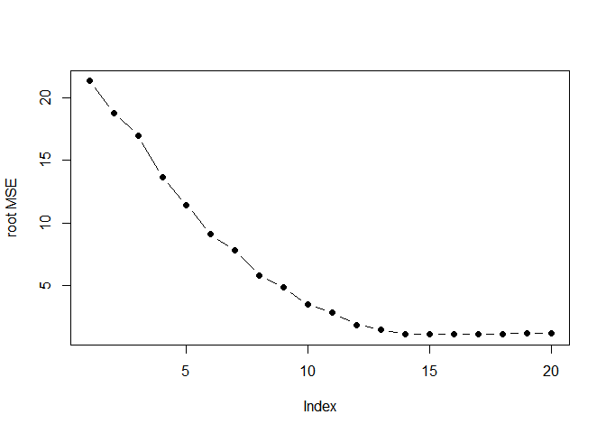

```r
#plot test mse
plot(sqrt(best.test.mes), ylab="root MSE", pch=19, type = "b")
```

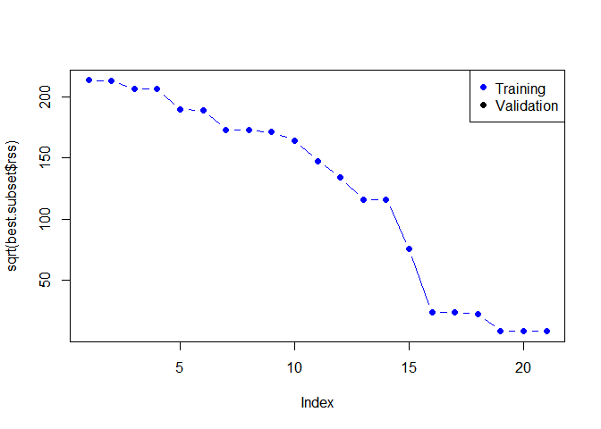

```r
plot(sqrt(best.subset$rss), col = "blue", pch = 19, type = "b")
legend("topright", legend = c("Training", "Validation"), col = c("blue", "black"),
    pch = 19)
```

5. For which model size does the test set MSE take on its minimum value? Comment on your results. If it takes on its minimum value for a model containing only an intercept or a model containing all of the features, then play around with the way that you are generating the data in (a) until you come up with a scenario in which the test set MSE is minimized for an intermediate model size.

```r
which.min(best.test.mes)
```

```
## [1] 14
```

```r
coef(best.subset,14)
```

```
## (Intercept)          X2          X3          X4          X6          X7
##  0.02084194  9.08362739  0.93547230  2.85823697  7.75679377  8.89869202
##          X8          X9         X11         X12         X13         X14
##  1.18350417  3.00004902  4.90483807  7.06633598  4.86875648  6.96389439
##         X16         X17         X19
##  2.09276483  7.83788468  2.05514114
```

6. How does the model at which the test set MSE is minimized compare to the true model used to generate the data? Comment on the coefficient values.

```r
coef(best.subset,14)
```

```
## (Intercept)          X2          X3          X4          X6          X7
##  0.02084194  9.08362739  0.93547230  2.85823697  7.75679377  8.89869202
##          X8          X9         X11         X12         X13         X14
##  1.18350417  3.00004902  4.90483807  7.06633598  4.86875648  6.96389439
##         X16         X17         X19
##  2.09276483  7.83788468  2.05514114
```

```r
b
```

```
##  [1] 0 9 1 3 0 8 9 1 3 0 5 7 5 7 0 2 8 0 2 0
```

```r
B = as.data.frame(t(b))
names(B) = paste0('X', 1:(ncol(B)))
coef.err=rep(NA,20)
for (i in 1:20){
  a=coef(best.subset,i)
  coef.err[i]=sqrt(sum(a[-1]-B[names(a)[-1]])^2)
}
coef.err
```

```
##  [1] 2.4161713 2.2930375 2.2509926 1.3929083 1.4792857 2.7852833 1.3116498
##  [8] 0.6850590 1.5719850 1.1009723 0.6785035 1.1986478 0.6982003 0.4940088
## [15] 0.2524062 0.3553227 0.5684206 0.5038616 0.3752642 0.4133320
```

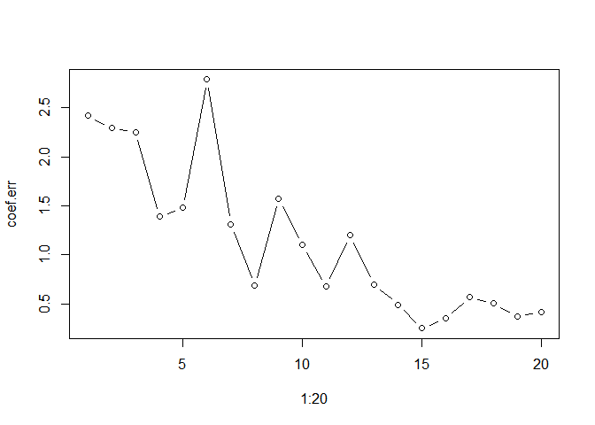

```r
plot(1:20,coef.err,type="b")
```

11. cross-validation

```r
k=10
set.seed(5)
folds=sample(1:k,nrow(df), replace=TRUE)
cv.errors =matrix (NA,k,20, dimnames =list(NULL , paste(1:20) ))
predict.regsubsets= function(object,newdata,id,...){
  form = as.formula(object$call[[2]])
  test.mat=model.matrix(form,newdata)
  coefi=coef(object,id=id)
  test.mat[,names(coefi)]%*%coefi
}
for (j in 1:k){
  best.fit=regsubsets(y~.,data = df[folds!=j,], nvmax = 20)
  for (i in 1:20){
    pred=predict(best.subset, df[folds==j,], id=i)
    cv.errors[j,i]=mean((df$y[folds==j]-pred)^2)}
}
cv.errors
```

```
##              1        2        3        4        5        6        7        8
##  [1,] 380.1216 313.6653 252.0753 177.2755 126.2971 79.63777 67.40668 33.41246
##  [2,] 391.2071 327.5276 317.7332 245.0256 153.6813 99.32366 66.67938 33.01987
##  [3,] 441.8289 317.4248 306.9440 186.9259 124.9847 86.61671 57.88150 32.62185
##  [4,] 485.7753 369.5134 289.0417 181.7306 137.0520 91.71197 68.30945 33.77196
##  [5,] 527.4407 414.6494 289.0578 195.3355 135.5963 76.42984 49.55550 30.85073
##  [6,] 478.9754 350.6017 294.6761 181.1165 112.6982 68.55003 54.78308 39.24953
##  [7,] 450.1290 373.2918 292.1953 183.2679 117.7069 73.66025 64.54322 39.55212
##  [8,] 358.9733 283.1159 220.9033 136.1212 110.3339 74.68186 51.48996 32.38688
##  [9,] 466.0364 381.3438 280.9152 178.2181 160.4935 89.16790 65.82947 35.70116
## [10,] 454.6895 306.0920 264.6022 169.6238 102.8024 64.74250 45.76716 24.01117
##              9       10       11       12       13       14        15        16
##  [1,] 22.31702 12.44231 8.983078 3.664248 2.285707 1.062132 1.0855625 1.0564141
##  [2,] 23.61979 12.44814 8.221395 3.777543 2.681016 1.339246 1.4155410 1.3892689
##  [3,] 22.75361 12.51197 7.829472 3.308790 2.146663 1.219594 1.4013984 1.3655358
```

[output cut: 18 more lines]

```r
mean.cv.errors=apply(cv.errors,2,mean)
which.min(mean.cv.errors)
```

```
## 14
## 14
```

```r
mean.cv.errors[14]  #test mse=1.1927
```

```
##     14
## 1.1927
```

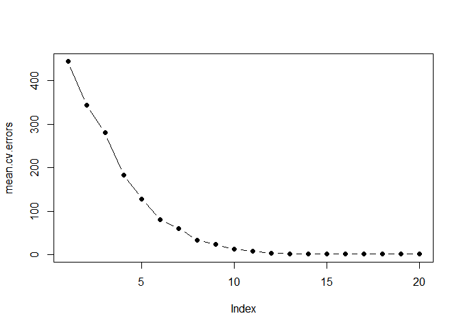

```r
plot(mean.cv.errors, pch = 19, type = "b")
```

```r
reg.best=regsubsets(y~., data=df, nvmax=20)
cv.coef=coef(reg.best,14)
coef(best.subset,14)
```

```
## (Intercept)          X2          X3          X4          X6          X7
##  0.02084194  9.08362739  0.93547230  2.85823697  7.75679377  8.89869202
##          X8          X9         X11         X12         X13         X14
##  1.18350417  3.00004902  4.90483807  7.06633598  4.86875648  6.96389439
##         X16         X17         X19
##  2.09276483  7.83788468  2.05514114
```

```r
cv.coef
```

```
## (Intercept)          X2          X3          X4          X6          X7
##  0.06712181  9.07719261  0.93535841  2.97378069  8.02238936  8.98412231
##          X8          X9         X11         X12         X13         X14
##  1.04942896  2.98915563  5.03211626  7.04104236  4.98826343  7.03259620
##         X16         X17         X19
##  1.98555325  8.00583513  2.01917143
```

```r
b
```

```
##  [1] 0 9 1 3 0 8 9 1 3 0 5 7 5 7 0 2 8 0 2 0
```